# cleaning

```python
import pandas as pd
import numpy as np
import matplotlib.pyplot as plt
import seaborn as sns
```

### Loading in data

```python
crimeDF = pd.read_csv('/Users/joeyposillico/Downloads/crimedata2.csv', encoding='ISO-8859-1')
crimeDF.head()
```

|  | Êcommunityname | state | countyCode | communityCode | fold | population | householdsize | racepctblack | racePctWhite | racePctAsian | ... | burglaries | burglPerPop | larcenies | larcPerPop | autoTheft | autoTheftPerPop | arsons | arsonsPerPop | ViolentCrimesPerPop | nonViolPerPop |
| --- | --- | --- | --- | --- | --- | --- | --- | --- | --- | --- | --- | --- | --- | --- | --- | --- | --- | --- | --- | --- | --- |
| 0 | BerkeleyHeightstownship | NJ | 39 | 5320 | 1 | 11980 | 3.10 | 1.37 | 91.78 | 6.50 | ... | 14 | 114.85 | 138 | 1132.08 | 16 | 131.26 | 2 | 16.41 | 41.02 | 1394.59 |
| 1 | Marpletownship | PA | 45 | 47616 | 1 | 23123 | 2.82 | 0.80 | 95.57 | 3.44 | ... | 57 | 242.37 | 376 | 1598.78 | 26 | 110.55 | 1 | 4.25 | 127.56 | 1955.95 |
| 2 | Tigardcity | OR | ? | ? | 1 | 29344 | 2.43 | 0.74 | 94.33 | 3.43 | ... | 274 | 758.14 | 1797 | 4972.19 | 136 | 376.3 | 22 | 60.87 | 218.59 | 6167.51 |
| 3 | Gloversvillecity | NY | 35 | 29443 | 1 | 16656 | 2.40 | 1.70 | 97.35 | 0.50 | ... | 225 | 1301.78 | 716 | 4142.56 | 47 | 271.93 | ? | ? | 306.64 | ? |
| 4 | Bemidjicity | MN | 7 | 5068 | 1 | 11245 | 2.76 | 0.53 | 89.16 | 1.17 | ... | 91 | 728.93 | 1060 | 8490.87 | 91 | 728.93 | 5 | 40.05 | ? | 9988.79 |

5 rows × 147 columns

```python
crimeDF.describe()
```

|  | fold | population | householdsize | racepctblack | racePctWhite | racePctAsian | racePctHisp | agePct12t21 | agePct12t29 | agePct16t24 | ... | PctBornSameState | PctSameHouse85 | PctSameCity85 | PctSameState85 | LandArea | PopDens | PctUsePubTrans | LemasPctOfficDrugUn | murders | murdPerPop |
| --- | --- | --- | --- | --- | --- | --- | --- | --- | --- | --- | --- | --- | --- | --- | --- | --- | --- | --- | --- | --- | --- |
| count | 2215.000000 | 2.215000e+03 | 2215.000000 | 2215.000000 | 2215.000000 | 2215.000000 | 2215.000000 | 2215.000000 | 2215.000000 | 2215.000000 | ... | 2215.000000 | 2215.000000 | 2215.000000 | 2215.000000 | 2215.000000 | 2215.000000 | 2215.000000 | 2215.000000 | 2215.000000 | 2215.000000 |
| mean | 5.494357 | 5.311798e+04 | 2.707327 | 9.335102 | 83.979819 | 2.670203 | 7.950176 | 14.445837 | 27.644840 | 13.975142 | ... | 61.539630 | 51.538596 | 77.411079 | 88.111865 | 27.419955 | 2783.835034 | 3.041124 | 0.980163 | 7.764786 | 5.859296 |
| std | 2.872924 | 2.046203e+05 | 0.334120 | 14.247156 | 16.419080 | 4.473843 | 14.589832 | 4.518623 | 6.181517 | 5.970747 | ... | 16.750061 | 10.517926 | 10.878186 | 7.287836 | 109.822600 | 2828.993341 | 4.912917 | 2.877128 | 58.166468 | 9.156829 |
| min | 1.000000 | 1.000500e+04 | 1.600000 | 0.000000 | 2.680000 | 0.030000 | 0.120000 | 4.580000 | 9.380000 | 4.640000 | ... | 6.750000 | 11.830000 | 27.950000 | 32.830000 | 0.900000 | 10.000000 | 0.000000 | 0.000000 | 0.000000 | 0.000000 |
| 25% | 3.000000 | 1.436600e+04 | 2.500000 | 0.860000 | 76.320000 | 0.620000 | 0.930000 | 12.250000 | 24.415000 | 11.320000 | ... | 50.110000 | 44.995000 | 72.060000 | 85.200000 | 7.300000 | 1181.900000 | 0.360000 | 0.000000 | 0.000000 | 0.000000 |
| 50% | 5.000000 | 2.279200e+04 | 2.660000 | 2.870000 | 90.350000 | 1.230000 | 2.180000 | 13.620000 | 26.780000 | 12.540000 | ... | 64.490000 | 52.170000 | 79.490000 | 90.030000 | 13.700000 | 2027.300000 | 1.220000 | 0.000000 | 1.000000 | 2.170000 |
| 75% | 8.000000 | 4.302400e+04 | 2.850000 | 11.145000 | 96.225000 | 2.670000 | 7.810000 | 15.360000 | 29.205000 | 14.345000 | ... | 74.855000 | 58.740000 | 85.135000 | 93.010000 | 26.100000 | 3321.700000 | 3.365000 | 0.000000 | 3.000000 | 8.365000 |
| max | 10.000000 | 7.322564e+06 | 5.280000 | 96.670000 | 99.630000 | 57.460000 | 95.290000 | 54.400000 | 70.510000 | 63.620000 | ... | 93.140000 | 78.560000 | 96.590000 | 99.900000 | 3569.800000 | 44229.900000 | 54.330000 | 48.440000 | 1946.000000 | 91.090000 |

8 rows × 104 columns

```python
crimeDF.shape
```

```
(2215, 147)
```

### Checking if any null values to deal with

```python
crimeDF.isna().sum()
```

```
Êcommunityname         0
state                  0
countyCode             0
communityCode          0
fold                   0
                      ..
autoTheftPerPop        0
arsons                 0
arsonsPerPop           0
ViolentCrimesPerPop    0
nonViolPerPop          0
Length: 147, dtype: int64
```

- there are no null values in this data set

```python
crimeDF.value_counts()
```

```
Êcommunityname          state  countyCode  communityCode  fold  population  householdsize  racepctblack  racePctWhite  racePctAsian  racePctHisp  agePct12t21  agePct12t29  agePct16t24  agePct65up  numbUrban  pctUrban  medIncome  pctWWage  pctWFarmSelf  pctWInvInc  pctWSocSec  pctWPubAsst  pctWRetire…
Aberdeencity            SD     13          100            6     24927       2.49           0.16          95.98         0.50          0.35         16.70        29.65        16.59        13.57       0          0.00      22422      75.49     3.09          48.52       31.39       5.10         11.57     …
Paducahcity             KY     ?           ?              6     27256       2.28           20.89         78.40         0.33          0.57         11.87        22.25        10.01        19.33       0          0.00      17196      61.90     0.36          33.74       41.14       12.47        19.07     …
Owossocity              MI     155         61940          4     16322       2.52           0.14          97.84         0.50          2.40         14.78        27.86        13.49        12.55       0          0.00      23220      71.65     0.78          38.41       30.64       11.92        16.52     …
Oxfordtown              MA     27          51825          2     12588       2.80           0.60          98.26         0.67          0.87         14.31        26.83        12.09        9.69        8449       67.12     36682      83.43     0.35          37.44       25.74       7.31         13.85     …
Oxnardcity              CA     ?           ?              4     142216      3.62           5.25          58.66         8.58          54.37        16.52        31.94        15.84        7.12        142192     100.00    37174      84.72     0.86          33.28       19.59       11.02        17.99     …
                                                                                                                                                                                                                                                                                                            …
Glendalecity            CA     ?           ?              1     180038      2.62           1.30          74.02         14.14         20.96        12.04        26.68        12.37        11.54       180038     100.00    34372      76.17     0.62          40.04       20.30       11.27        11.51     …
                        AZ     ?           ?              10    148134      2.76           3.01          84.98         2.13          15.47        15.88        29.88        14.54        7.10        148134     100.00    31665      84.20     0.40          36.59       18.21       5.13         13.69     …
GlendaleHeightsvillage  IL     ?           ?              2     27973       2.91           2.77          81.67         13.29         6.17         14.07        33.10        14.07        3.94        27973      100.00    42822      94.04     0.49          43.98       10.73       2.75         6.09      …
GlenRockborough         NJ     3           26640          8     10883       2.83           2.21          91.69         5.95          1.90         11.31        19.12        8.98         14.11       10883      100.00    65976      81.91     0.59          68.08       30.53       1.00         19.48     …
Zanesvillecity          OH     119         88084          2     26778       2.48           10.76         88.29         0.20          0.40         13.40        25.87        12.63        14.72       0          0.00      17658      65.57     0.41          29.65       36.76       16.41        19.11     …
Name: count, Length: 2215, dtype: int64
```

- Here we can see that although there are no null values there are a bunch of '?' values that will need to be dealt with

### dealing with '?' values

```python
rows_with_question_mark = crimeDF.isin(['?']).any(axis=1).sum()
print(rows_with_question_mark)
```

```
2104
```

- 2104 rows contain a question mark this is a significant amount.

```python
question_mark_counts = crimeDF.isin(['?']).sum()
print(question_mark_counts)
most_question_marks = question_mark_counts.sort_values(ascending=False)
print(most_question_marks)
```

```
Êcommunityname            0
state                     0
countyCode             1221
communityCode          1224
fold                      0
                       ...
autoTheftPerPop           3
arsons                   91
arsonsPerPop             91
ViolentCrimesPerPop     221
nonViolPerPop            97
Length: 147, dtype: int64
PctPolicBlack          1872
PolicAveOTWorked       1872
PolicOperBudg          1872
LemasPctPolicOnPatr    1872
LemasGangUnitDeploy    1872
                       ...
PctTeen2Par               0
PctWorkMomYoungKids       0
PctWorkMom                0
NumKidsBornNeverMar       0
PctPersDenseHous          0
Length: 147, dtype: int64
```

- here we see that the '?' are more prominent in certain columns and therefore before deciding what to do with them we will break our DF into a subset of the columns we plan on using to get a better idea of how we'll deal with them

```python
crimeDF2 = crimeDF
crimeDF2['PctNotHSGrad'] = crimeDF['PctNotHSGrad'].apply(lambda x :
    '0%-10%' if 0 <= x <= 10 else
    '10%-20%' if 10 <= x <=20 else
    '20%-30%' if 20 <= x <=30 else
    '30%-40%' if 30 <= x <=40 else
    '40%-50%' if 40 <= x <=50 else
    '50%-60%' if 50 <= x <=60 else
    '60%-70%' if 60 <= x <=70 else
    '70%-80%' if 70 <= x <=80 else
    '80%-90%' if 80 <= x <=90 else
    '90%-100%' if 90 <= x <=100 else x
    )
```

- breaking down pctNotHSGrad into subsections for easier use

```python
onlyCrime = crimeDF2[['PctNotHSGrad', 'ViolentCrimesPerPop', 'nonViolPerPop', 'arsonsPerPop', 'autoTheftPerPop', 'larcPerPop', 'burglPerPop', 'assaultPerPop', 'robbbPerPop', 'rapesPerPop', 'murdPerPop']]
onlyCrime.columns
```

```
Index(['PctNotHSGrad', 'ViolentCrimesPerPop', 'nonViolPerPop', 'arsonsPerPop',
       'autoTheftPerPop', 'larcPerPop', 'burglPerPop', 'assaultPerPop',
       'robbbPerPop', 'rapesPerPop', 'murdPerPop'],
      dtype='object')
```

- created a new DF that contains just the variables we plan on using

```python
rows_with_question_mark = onlyCrime.isin(['?']).any(axis=1).sum()
print(rows_with_question_mark)
print(onlyCrime.shape)
```

```
313
(2215, 11)
```

- with our smaller DF we can now see that there are only 313 rows with '?' which is only 14% of the data.

```python
question_mark_counts_cleaned = onlyCrime.isin(['?']).sum()
print(question_mark_counts_cleaned)
```

```
PctNotHSGrad             0
ViolentCrimesPerPop    221
nonViolPerPop           97
arsonsPerPop            91
autoTheftPerPop          3
larcPerPop               3
burglPerPop              3
assaultPerPop           13
robbbPerPop              1
rapesPerPop            208
murdPerPop               0
dtype: int64
```

```python
onlyCrime.count()
```

```
PctNotHSGrad           2215
ViolentCrimesPerPop    2215
nonViolPerPop          2215
arsonsPerPop           2215
autoTheftPerPop        2215
larcPerPop             2215
burglPerPop            2215
assaultPerPop          2215
robbbPerPop            2215
rapesPerPop            2215
murdPerPop             2215
dtype: int64
```

- here we see that each category has 2215, since there are at most 221 '?' in a single column (violentCrimesPerPop) we will drop these rows

### Dropping the '?' rows

```python
# Replace '?' with NaN
onlyCrime.replace('?', np.nan, inplace=True)
onlyCrime.isna().sum()
```

```
PctNotHSGrad             0
ViolentCrimesPerPop    221
nonViolPerPop           97
arsonsPerPop            91
autoTheftPerPop          3
larcPerPop               3
burglPerPop              3
assaultPerPop           13
robbbPerPop              1
rapesPerPop            208
murdPerPop               0
dtype: int64
```

- turns the '?' values into NaN values so that they are easier to drop

```python
# Drop rows with NaN values
onlyCrime.dropna(inplace=True)
print(onlyCrime.isna().sum())
```

```
PctNotHSGrad           0
ViolentCrimesPerPop    0
nonViolPerPop          0
arsonsPerPop           0
autoTheftPerPop        0
larcPerPop             0
burglPerPop            0
assaultPerPop          0
robbbPerPop            0
rapesPerPop            0
murdPerPop             0
dtype: int64
```

```python
print(onlyCrime.shape)
```

```
(1902, 11)
```

- no more '?' values. 313 total rows dropped, 14% of the data

### Checking to make sure columns are in the correct data type

```python
#checking data type for each column
onlyCrime.dtypes
```

```
PctNotHSGrad            object
ViolentCrimesPerPop     object
nonViolPerPop           object
arsonsPerPop            object
autoTheftPerPop         object
larcPerPop              object
burglPerPop             object
assaultPerPop           object
robbbPerPop             object
rapesPerPop             object
murdPerPop             float64
dtype: object
```

```python
#change data type of all columns to float except for PctNotHSGrad
onlyCrime[onlyCrime.columns[1:]] = onlyCrime[onlyCrime.columns[1:]].astype(float)
onlyCrime.dtypes
```

```
PctNotHSGrad            object
ViolentCrimesPerPop    float64
nonViolPerPop          float64
arsonsPerPop           float64
autoTheftPerPop        float64
larcPerPop             float64
burglPerPop            float64
assaultPerPop          float64
robbbPerPop            float64
rapesPerPop            float64
murdPerPop             float64
dtype: object
```

- changed all rows to floats, except for PctnotHSGrad because that column got changed to categorical instead of numbers

### Dealing with outliers

- step one visualize to determine if there are many outliers that needs to be dealt with

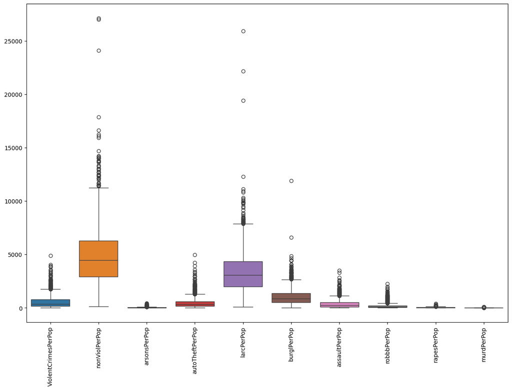

```python
# Boxplot for each column to visualize outliers
plt.figure(figsize=(15, 10))
sns.boxplot(data=onlyCrime)
plt.xticks(rotation=90)
plt.show()
```

```python
import numpy as np
from scipy import stats


# Select only numerical columns
numerical_columns = onlyCrime.select_dtypes(include=[np.number])

# Calculate Z-scores for numerical columns
z_scores = stats.zscore(numerical_columns)

# Filter out rows with Z-scores greater than 3 or less than -3
onlyCrime_no_outliers = onlyCrime[(np.abs(z_scores) < 3).all(axis=1)]
```

- selected only the numerical columns (only one we don't touch here is PctNotHSGrad).
- in order to find and remove outliers we used z-score which measures how far the data oint is from the mean in relation with the standard deviation. If the score was greater than 3 or less than -3 this indicates that the data point is different from the other data points and therefore are removed as outliers.

```python
onlyCrime_no_outliers.shape
```

```
(1738, 11)
```

### Plotting the original box plot with the new box plot to make sure the above code worked as intended

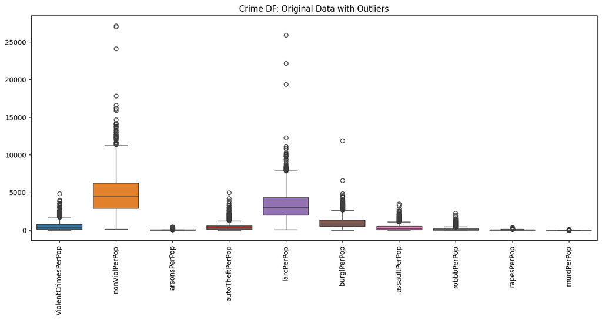

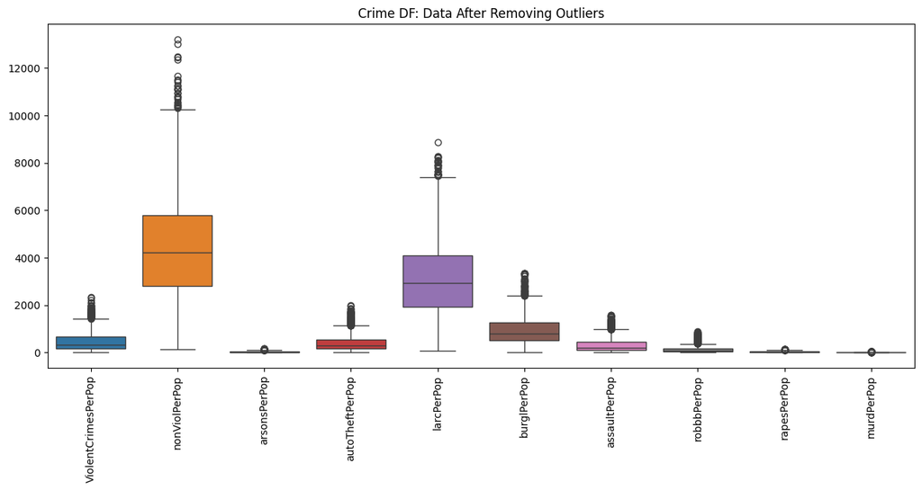

```python
# Boxplot for the original data
plt.figure(figsize=(15, 6))
sns.boxplot(data=numerical_columns)
plt.title("Crime DF: Original Data with Outliers")
plt.xticks(rotation=90)
plt.show()

# Boxplot for the data without outliers
plt.figure(figsize=(15, 6))
sns.boxplot(data=onlyCrime_no_outliers.select_dtypes(include=[np.number]))
plt.title("Crime DF: Data After Removing Outliers")
plt.xticks(rotation=90)
plt.show()
```

- putting them side by side for better using in our project

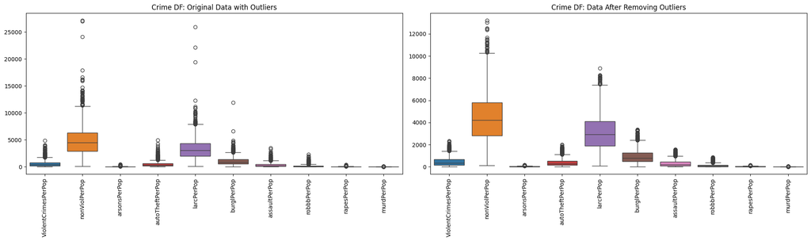

```python
# Create a figure and two subplots side by side
fig, axes = plt.subplots(1, 2, figsize=(20, 6))

# Boxplot for the original data with outliers
sns.boxplot(data=numerical_columns, ax=axes[0])
axes[0].set_title("Crime DF: Original Data with Outliers")
axes[0].tick_params(axis='x', rotation=90)

# Boxplot for the data without outliers
sns.boxplot(data=onlyCrime_no_outliers.select_dtypes(include=[np.number]), ax=axes[1])
axes[1].set_title("Crime DF: Data After Removing Outliers")
axes[1].tick_params(axis='x', rotation=90)

# Display the plots
plt.tight_layout()
plt.show()
```

- shows that although there are still a few outliers, highest outliers have been dealt with and removed so that they do not negatively affect or modeling.

### Going to repeat these previous steps but now do it with income variables

```python
income = ['medIncome', 'pctWWage', 'pctWSocSec', 'pctWInvInc',
                     'medFamInc', 'NumUnderPov', 'PctPopUnderPov', 'pctWPubAsst']
onlyIncome = crimeDF[income]
onlyIncome.columns
```

```
Index(['medIncome', 'pctWWage', 'pctWSocSec', 'pctWInvInc', 'medFamInc',
       'NumUnderPov', 'PctPopUnderPov', 'pctWPubAsst'],
      dtype='object')
```

#### Checking for null '?' values

```python
question_mark_counts = onlyIncome.isin(['?']).sum()
print(question_mark_counts)
most_question_marks = question_mark_counts.sort_values(ascending=False)
print(most_question_marks)
```

```
medIncome         0
pctWWage          0
pctWSocSec        0
pctWInvInc        0
medFamInc         0
NumUnderPov       0
PctPopUnderPov    0
pctWPubAsst       0
dtype: int64
medIncome         0
pctWWage          0
pctWSocSec        0
pctWInvInc        0
medFamInc         0
NumUnderPov       0
PctPopUnderPov    0
pctWPubAsst       0
dtype: int64
```

- no '?' values present inside this subset DF

```python
onlyIncome.isna().sum()
```

```
medIncome         0
pctWWage          0
pctWSocSec        0
pctWInvInc        0
medFamInc         0
NumUnderPov       0
PctPopUnderPov    0
pctWPubAsst       0
dtype: int64
```

- no null values present inside this subset DF

#### Checking to make sure they are correct data types

```python
onlyIncome.dtypes
```

```
medIncome           int64
pctWWage          float64
pctWSocSec        float64
pctWInvInc        float64
medFamInc           int64
NumUnderPov         int64
PctPopUnderPov    float64
pctWPubAsst       float64
dtype: object
```

```python
onlyIncome.shape
```

```
(2215, 8)
```

#### Checking for outliers

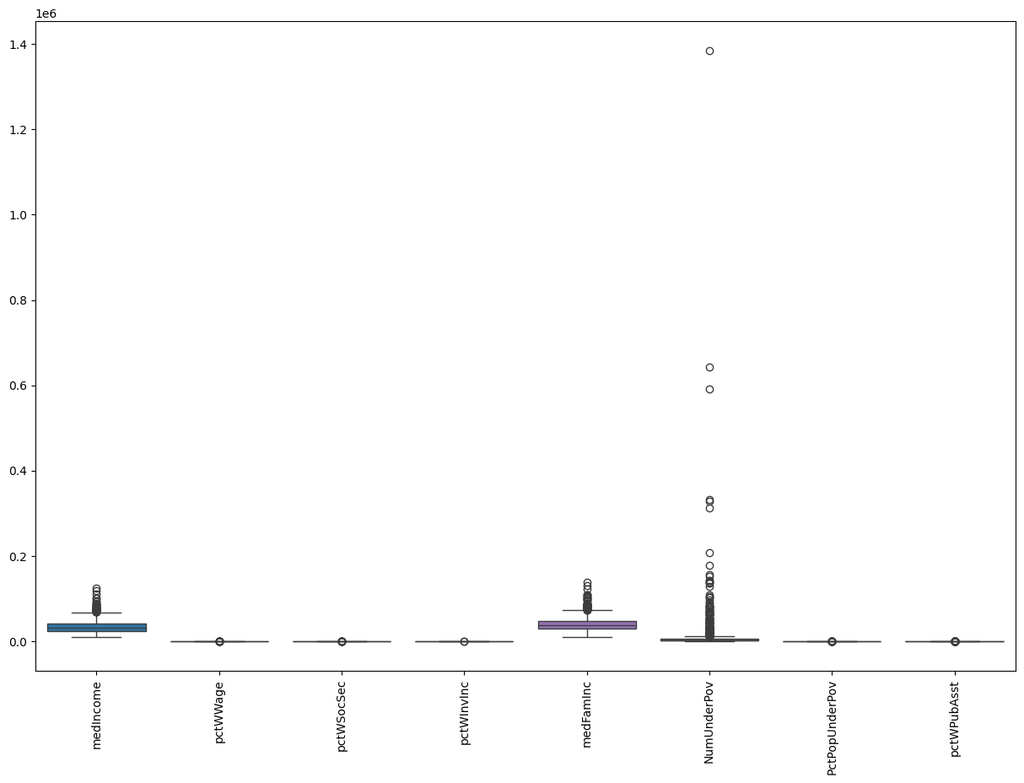

```python
# Boxplot for each column to visualize outliers
plt.figure(figsize=(15, 10))
sns.boxplot(data=onlyIncome)
plt.xticks(rotation=90)
plt.show()
```

- most obvious outliers seem to be in the NumUnderPov category

```python
# Calculate Z-scores for numerical columns
z_scores = stats.zscore(onlyIncome)

# Filter out rows with Z-scores greater than 3 or less than -3
onlyIncome_no_outliers = onlyIncome[(np.abs(z_scores) < 3).all(axis=1)]
```

- as explained earlier, z-score performed to identify and remove outliers

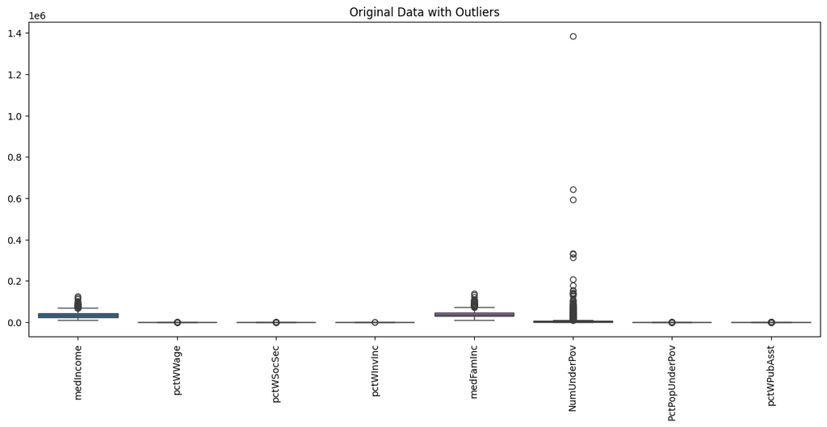

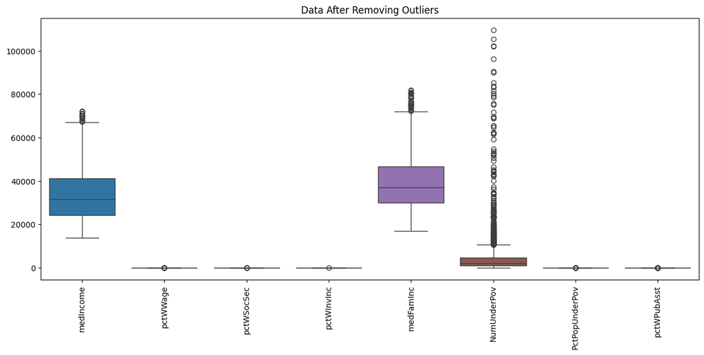

```python
# Boxplot for the original data
plt.figure(figsize=(15, 6))
sns.boxplot(data=onlyIncome)
plt.title("Original Data with Outliers")
plt.xticks(rotation=90)
plt.show()

# Boxplot for the data without outliers
plt.figure(figsize=(15, 6))
sns.boxplot(data=onlyIncome_no_outliers.select_dtypes(include=[np.number]))
plt.title("Data After Removing Outliers")
plt.xticks(rotation=90)
plt.show()
```

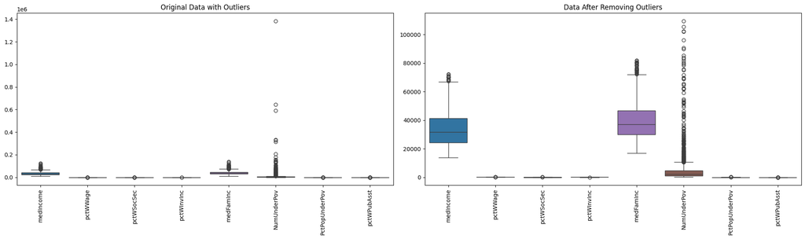

```python
# Create a figure and two subplots side by side
fig, axes = plt.subplots(1, 2, figsize=(20, 6))

# Boxplot for the original data with outliers
sns.boxplot(data=onlyIncome, ax=axes[0])
axes[0].set_title("Original Data with Outliers")
axes[0].tick_params(axis='x', rotation=90)

# Boxplot for the data without outliers
sns.boxplot(data=onlyIncome_no_outliers.select_dtypes(include=[np.number]), ax=axes[1])
axes[1].set_title("Data After Removing Outliers")
axes[1].tick_params(axis='x', rotation=90)

# Display the plots
plt.tight_layout()
plt.show()
```

- visualizing to make sure that we got the intended outcome while removing outliers

```python
print(onlyIncome.shape)
print(onlyIncome_no_outliers.shape)
```

```
(2215, 8)
(2104, 8)
```

- removed 111 outliers (~5% of data)